# Practical work on LDA

The goal is to apply LDA on the Wine data set, which is avalaible in the `pgmm` package.

# Preparation of the data

```r
# we'll use this package to load the data
#install.packages("pgmm"); install.packages('mvtnorm')
library(pgmm); library(mvtnorm)
```

Once the packages are loaded, we can load the data in the environment.

```r
data(wine)
head(wine)
```

|  | Type | Alcohol | Sugar-free Extract | Fixed Acidity | Tartaric Acid | Malic Acid | Uronic Acids | pH | Ash | Alcalinity of Ash | Potassium | Calcium | Magnesium | Phosphate | Chloride | Total Phenols | Flavanoids | Non-flavanoid Phenols | Proanthocyanins | Color Intensity | Hue | OD280/OD315 of Diluted Wines | OD280/OD315 of Flavanoids | Glycerol | 2-3-Butanediol | Total Nitrogen | Proline | Methanol |
| --- | --- | --- | --- | --- | --- | --- | --- | --- | --- | --- | --- | --- | --- | --- | --- | --- | --- | --- | --- | --- | --- | --- | --- | --- | --- | --- | --- | --- |
| 1 | 1 | 14.23 | 24.82 | 73.1 | 1.21 | 1.71 | 0.72 | 3.38 | 2.43 | 15.6 | 950 | 62 | 127 | 320 | 82 | 2.80 | 3.06 | 0.28 | 2.29 | 5.64 | 1.04 | 3.92 | 4.77 | 9.29 | 757 | 153 | 1065 | 113 |
| 2 | 1 | 13.20 | 26.30 | 72.8 | 1.84 | 1.78 | 0.71 | 3.30 | 2.14 | 11.2 | 765 | 75 | 100 | 395 | 90 | 2.65 | 2.76 | 0.26 | 1.28 | 4.38 | 1.05 | 3.40 | 3.80 | 8.93 | 881 | 194 | 1050 | 94 |
| 3 | 1 | 13.16 | 26.30 | 68.5 | 1.94 | 2.36 | 0.84 | 3.48 | 2.67 | 18.6 | 936 | 70 | 101 | 497 | 67 | 2.80 | 3.24 | 0.30 | 2.81 | 5.68 | 1.03 | 3.17 | 3.46 | 11.74 | 900 | 206 | 1185 | 125 |
| 4 | 1 | 14.37 | 25.85 | 74.9 | 1.59 | 1.95 | 0.72 | 3.43 | 2.50 | 16.8 | 985 | 47 | 113 | 580 | 49 | 3.85 | 3.49 | 0.24 | 2.18 | 7.80 | 0.86 | 3.45 | 3.54 | 10.13 | 1119 | 292 | 1480 | 80 |
| 5 | 1 | 13.24 | 26.05 | 83.5 | 1.30 | 2.59 | 1.10 | 3.42 | 2.87 | 21.0 | 1088 | 70 | 118 | 408 | 65 | 2.80 | 2.69 | 0.39 | 1.82 | 4.32 | 1.04 | 2.93 | 3.22 | 10.27 | 799 | 215 | 735 | 73 |
| 6 | 1 | 14.20 | 28.40 | 79.9 | 2.14 | 1.76 | 0.96 | 3.39 | 2.45 | 15.2 | 868 | 71 | 112 | 418 | 58 | 3.27 | 3.39 | 0.34 | 1.97 | 6.75 | 1.05 | 2.85 | 3.16 | 10.85 | 865 | 364 | 1450 | 68 |

The documentation of the data can provide some additional informtation about the data:

```r
?wine
```

To simplify the data set at first, let’s consider only 2 variables and two classes (Barolo vs Grignolino and Barbera):

```r
X = as.matrix(wine[,c(2,4)])
dim(X)
```

```
## [1] 178   2
```

```r
colnames(X)
```

```
## [1] "Alcohol"       "Fixed Acidity"
```

```r
z = as.numeric(wine$Type!=1) + 1
```

It is of course possible to look at the data:

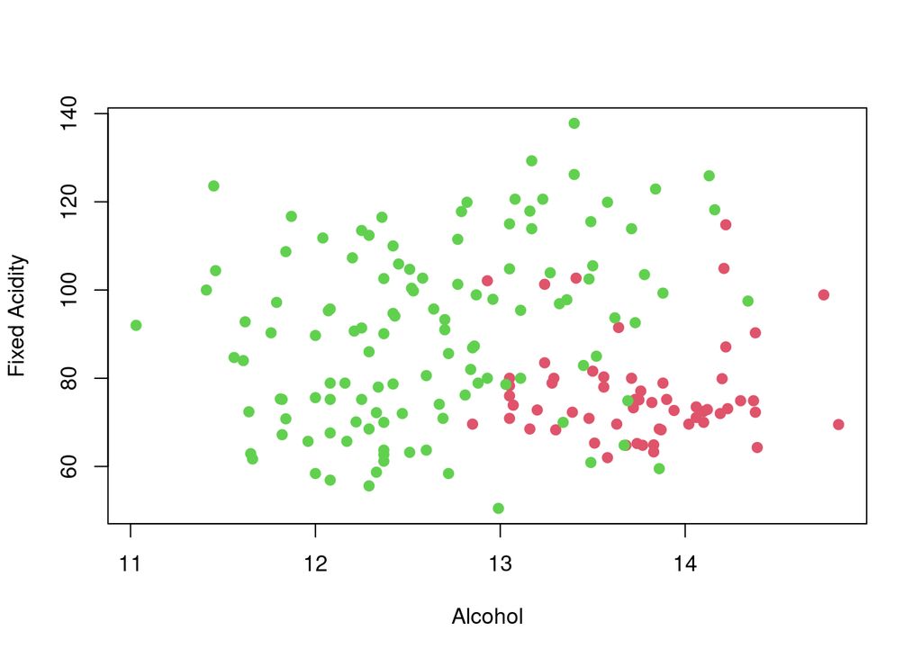

```r
plot(X, col = z+1, pch=19)
```

# Classification with LDA

In order to classify those data with LDA:

- the first step is to learn the LDA model from the data (i.e. estimate form the data the model parameters)
- then, once the model is learned, we will be able to classify new data to one of the two classes.

LDA assumes the following model:

$$p(x|Z=k;\mu,\Sigma) = \mathcal{N}(x;\mu_k,\Sigma)$$

and $P(Z=k) = \pi_k$.

The ML estimation conduices to the following updates:

- $$\hat{\pi}_k = \sum_{i=1}^n 1(z_i = k) / n$$
- $$\hat{\mu_k} = \sum_{i=1}^n 1(z_i = k) x_i / n_k$$
- $$\hat{\Sigma} = \frac{1}{n}\sum_{k=1}^K n_k S_k$$

where
$$S_k = \frac{1}{n_k}\sum_{i=1}^n 1(z_i = k) (x_i -\hat{\mu_k})^t (x_i -\hat{\mu_k})$$

Let’s now code that…

```r
lda.learn <- function(X,z){
  n = nrow(X); p = ncol(X)
  K = max(z)
  prop = rep(NA,K)
  mu = matrix(NA,K,p)
  Sigma = matrix(0,p,p)
  for (k in 1:K){
    nk = sum(z == k)
    prop[k] =  nk / n
    mu[k,] = colSums(X[z == k,]) / nk
    Sigma = Sigma + nk / n * cov(X[z == k,])
  }
  return(list(prop = prop, mu = mu, Sigma = Sigma))
}

params = lda.learn(X,z)
params
```

```
## $prop
## [1] 0.3314607 0.6685393
##
## $mu
##          [,1]     [,2]
## [1,] 13.74475 76.72203
## [2,] 12.63168 90.06639
##
## $Sigma
##                 Alcohol Fixed Acidity
## Alcohol       0.3846606      2.708836
## Fixed Acidity 2.7088362    311.991616
```

For the classification step, we use the Maximum A Posteriori (MAP) rule:

$$z^* = argmax_k P(Z=k|X=x^*)$$

To compute those posterior probabilities from the data and the learned parameter, we can rely on the Bayes’ rule:

$$P(Z=k|X=x^*,\hat{\theta}) = \frac{P(Z=k|\hat{\theta})p(x^*|Z=k,\hat{\theta})}{p(X)}$$
$$P(Z=k|X=x^*,\hat{\theta}) = \frac{\hat{\pi}_k\phi(x^*|\hat{\mu}_k,\hat{\Sigma})}{p(X)}$$

where $\phi$ is the pdf of the Gaussian distribution.

So, the prediction step of LDA resumes to the computation of the $K$ posterior probabilities $P(Z=k|X=x^*)$ with the above formula:

```r
lda.predict <- function(xstar,params){
  K = length(params$prop)
  Prob = matrix(NA,nrow(xstar),K)
  for (k in 1:K){
    Prob[,k] = params$prop[k] * dmvnorm(xstar,params$mu[k,],params$Sigma)
  }
  Prob = t(apply(Prob,1,function(x){x / sum(x)}))
  zstar = apply(Prob,1,which.max)
  return(list(Prob = Prob,zstar = zstar))
}

out = lda.predict(X,params)
head(out$Prob)
```

```
##           [,1]       [,2]
## [1,] 0.9730892 0.02691077
## [2,] 0.5261417 0.47385827
## [3,] 0.5694259 0.43057415
## [4,] 0.9808137 0.01918634
## [5,] 0.3698148 0.63018521
## [6,] 0.9523072 0.04769278
```

```r
head(out$zstar)
```

```
## [1] 1 1 1 1 2 1
```

# Classification of the whole data set

Let’s now come back on the full 3-class wine data set and classify it with LDA, using the minimal setup (splitting the data in learning and validation sets) to evaluate in a correct way the performance of LDA on this problem.

```r
X = wine[,-1]
z = wine$Type

learn = sample(nrow(X),130)

params = lda.learn(X[learn,],z[learn])
out = lda.predict(X[-learn,],params)

cat('Classification table:\n')
```

```
## Classification table:
```

```r
table(z[-learn],out$zstar)
```

```
##
##      1  2  3
##   1 15  0  0
##   2  1 18  0
##   3  0  0 14
```

```r
cat('\nError rate:',sum(z[-learn] != out$zstar) / length(z[-learn]))
```

```
##
## Error rate: 0.02083333
```